# Cytomegalovirus

[figure not shown]

[figure not shown]

[figure not shown]

[figure not shown]

[figure not shown]

[figure not shown]

# EDA

### Stars plot

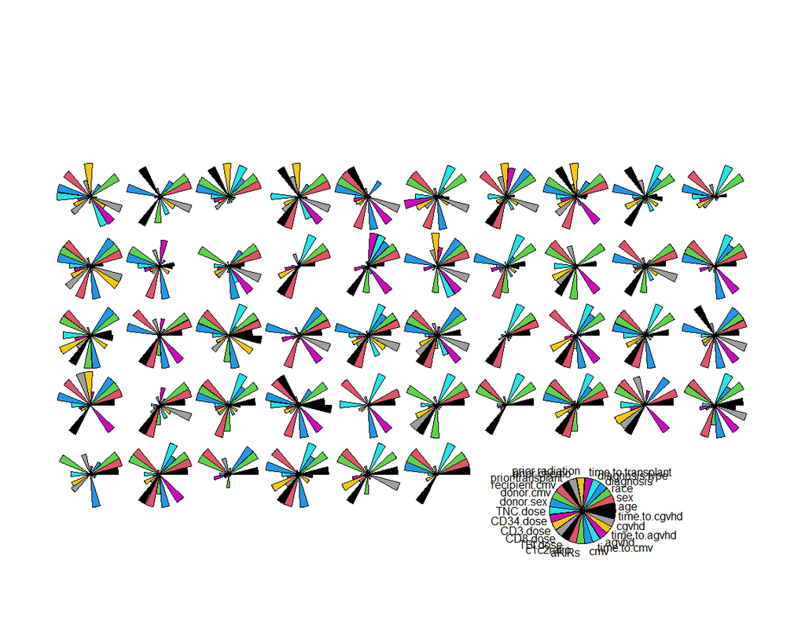

### Age vs Frequency

[interactive chart not shown]

### Diagnosis Types & Frequencies

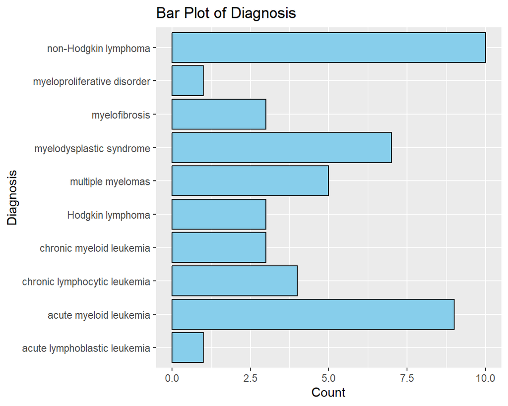

### Correlation plot

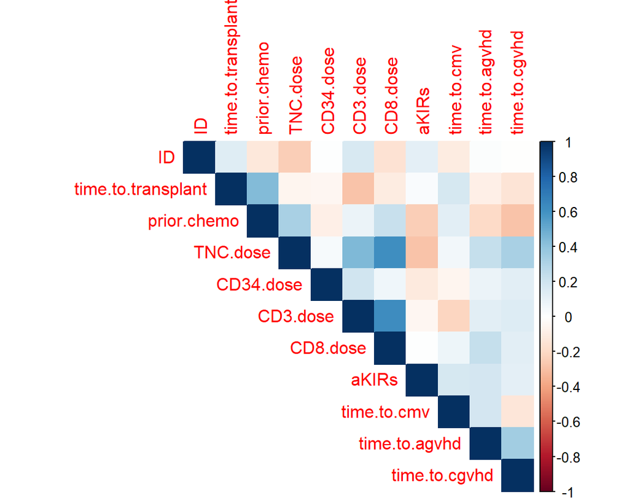

## Comment tabs

### Comment

# Distributions of Numerical variables

### Chart

[interactive chart not shown]

### Chart

[interactive chart not shown]

### Chart

[interactive chart not shown]

# Distributions for numerical variables

### Chart

[interactive chart not shown]

### Chart

[interactive chart not shown]

### Chart

[interactive chart not shown]

# Relation Plots

### Age VS Time from cancer diagnosis to transplant (months)

[interactive chart not shown]

### Age Vs Time to cytomegalovirus reactivation

[interactive chart not shown]

## comment tab

### Comment

-The density lines are concenctrated at the age 60. Which means, if the age of patients are close to 60, the time from cancer diagnosis to transplant decreases. But still, there are some patients whose age are under 40 and their time from diagnosis to transplant is low.

# Relation Plots

### Chart

[interactive chart not shown]

# Relation Plots

### Chart

[interactive chart not shown]

### ChartB

[interactive chart not shown]

### Chart

[interactive chart not shown]

## comment tab

### Comment

In these plots, we can clearly see that when TNC dose and CD3 dose increase,the CD8 dose also increase, which we observed in the correlation graph.

# Relation Plots

### ChartA

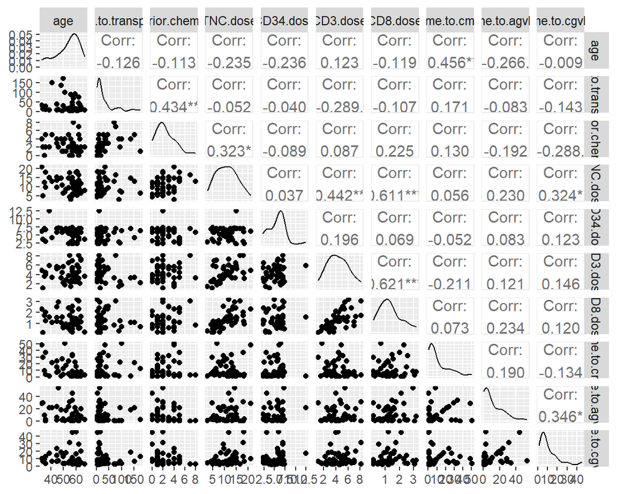

# Contingency table analysis

### Gender vs Diagnosis Type

```
        Diagnosis_Type
Sex      Myeloid Lymphoid
  Male         9       11
  Female      14       12
```

### Odds Ratio

```
 estimate     lower     upper
0.7012987 0.2175053 2.2611859
```

The odds ratio indicates that females have approximately 70% of the odds of being diagnosed with Myeloid or Lymphoid type compared to males.However, 95% Wald Confidence Interval suggests that there is no significant association between gender and diagnosis type. Because the interval includes 1.

### Chi-Squared Test of Independence

H0: The variables in row and column are independent H0: The variables in row and column are NOT independent

```
    Pearson's Chi-squared test with Yates' continuity correction

data:  x2table
X-squared = 0.088462, df = 1, p-value = 0.7661
```

Our P-value is 0.76 ,which is greater than our alpha value 0.05 , we fail to reject null hypotesis. meaning that the variables are NOT associated.

# Contingency table analysis

### Race vs Diagnosis Type

```
                  Diagnosis_Type
Race               Myeloid Lymphoid
  White                  3        1
  American/African      20       22
```

### Odds Ratio

```
  estimate      lower      upper
 3.3000000  0.3169979 34.3535362
```

The odds ratio indicates that odds of American/African people being diagnosed with Myeloid or Lymphoid type is 3.3 times when compared to white people.

### Chi-squared Test

H0: The variables in row and column are independent H0: The variables in row and column are NOT independent

```
    Pearson's Chi-squared test with Yates' continuity correction

data:  x2table2
X-squared = 0.27381, df = 1, p-value = 0.6008
```

We got a warning about Chi-square may be incorrect. Thats because Chi square statistic follows chi-squared distribution approximately. Chisq.test function warns us we have one expected count lower than 5.So, it is better to use Fisher’s Exact Test.

### Fisher’s Exact Test

```
    Fisher's Exact Test for Count Data

data:  x2table2
p-value = 0.6078
alternative hypothesis: true odds ratio is not equal to 1
95 percent confidence interval:
   0.2364028 180.7741745
sample estimates:
odds ratio
  3.220884
```

P value being greater than 0.05 indicates we fail to reject H0,which means the race and diagnosis type is also not related to eachother.

# PMB (Purposeful selection for Modeling)

### Train & test data

```
 [1] "ID"                 "age"                "sex"                "race"               "diagnosis"          "diagnosis.type"
 [7] "time.to.transplant" "prior.radiation"    "prior.chemo"        "prior.transplant"   "recipient.cmv"      "donor.cmv"
[13] "donor.sex"          "TNC.dose"           "CD34.dose"          "CD3.dose"           "CD8.dose"           "TBI.dose"
[19] "c1c2ratio"          "aKIRs"              "cmv"                "time.to.cmv"        "agvhd"              "time.to.agvhd"
[25] "cgvhd"              "time.to.cgvhd"
```

.

### 1) Constructing main effect models & collecting variables (if P<0.2)

```
$ID

Call:
glm(formula = paste("cmv ~", var), family = "binomial", data = traindata)

Coefficients:
             Estimate Std. Error z value Pr(>|z|)
(Intercept) -0.593585   0.680282  -0.873    0.383
ID           0.004142   0.016795   0.247    0.805

(Dispersion parameter for binomial family taken to be 1)

    Null deviance: 54.846  on 40  degrees of freedom
Residual deviance: 54.785  on 39  degrees of freedom
AIC: 58.785

Number of Fisher Scoring iterations: 4


$age

Call:
glm(formula = paste("cmv ~", var), family = "binomial", data = traindata)

Coefficients:
            Estimate Std. Error z value Pr(>|z|)
(Intercept) -2.86146    2.18728  -1.308    0.191
age          0.04459    0.03957   1.127    0.260

(Dispersion parameter for binomial family taken to be 1)

    Null deviance: 54.846  on 40  degrees of freedom
Residual deviance: 53.475  on 39  degrees of freedom
AIC: 57.475

Number of Fisher Scoring iterations: 4


$sex

```

[output cut: 442 more lines]

```

Coefficients:
              Estimate Std. Error z value Pr(>|z|)
(Intercept)   -1.73852    0.61563  -2.824  0.00474 **
time.to.cgvhd  0.11664    0.04925   2.368  0.01787 *
---
Signif. codes:  0 '***' 0.001 '**' 0.01 '*' 0.05 '.' 0.1 ' ' 1

(Dispersion parameter for binomial family taken to be 1)

    Null deviance: 54.846  on 40  degrees of freedom
Residual deviance: 45.743  on 39  degrees of freedom
AIC: 49.743

Number of Fisher Scoring iterations: 4
```

In the p values, we see that ID,age,sex,diagnosis,race,time.to.transplant,prior.radiation, recipient.cmv,donor.sex,doses of TNC,DC3,DC8,DC34,aKIRs,time.to.cmv are insignificant.

### Full model & backward elimination

```
Call:
glm(formula = cmv ~ . - age - race - diagnosis - ID - sex - time.to.transplant -
    prior.radiation - recipient.cmv - donor.sex - TNC.dose -
    CD3.dose - CD8.dose - CD34.dose - aKIRs - time.to.cmv, family = "binomial",
    data = traindata)

Coefficients:
                  Estimate Std. Error z value Pr(>|z|)
(Intercept)       1.541782   4.090248   0.377   0.7062
diagnosis.type   -1.312036   1.854786  -0.707   0.4793
prior.chemo      -0.452313   0.556938  -0.812   0.4167
prior.transplant -3.543933   2.397043  -1.478   0.1393
donor.cmv         0.718393   1.028254   0.699   0.4848
TBI.dose         -0.011697   0.006311  -1.853   0.0638 .
c1c2ratio         2.214145   1.283232   1.725   0.0844 .
agvhd             2.380332   1.353598   1.759   0.0787 .
time.to.agvhd     0.016717   0.061449   0.272   0.7856
cgvhd            -1.473559   1.411957  -1.044   0.2967
time.to.cgvhd     0.123472   0.089470   1.380   0.1676
---
Signif. codes:  0 '***' 0.001 '**' 0.01 '*' 0.05 '.' 0.1 ' ' 1

(Dispersion parameter for binomial family taken to be 1)

    Null deviance: 54.846  on 40  degrees of freedom
Residual deviance: 28.095  on 30  degrees of freedom
AIC: 50.095

Number of Fisher Scoring iterations: 6
```

```
Start:  AIC=50.09
cmv ~ (ID + age + sex + race + diagnosis + diagnosis.type + time.to.transplant +
    prior.radiation + prior.chemo + prior.transplant + recipient.cmv +
    donor.cmv + donor.sex + TNC.dose + CD34.dose + CD3.dose +
    CD8.dose + TBI.dose + c1c2ratio + aKIRs + time.to.cmv + agvhd +
    time.to.agvhd + cgvhd + time.to.cgvhd) - age - race - diagnosis -
    ID - sex - time.to.transplant - prior.radiation - recipient.cmv -
    donor.sex - TNC.dose - CD3.dose - CD8.dose - CD34.dose -
    aKIRs - time.to.cmv

                   Df Deviance    AIC
- time.to.agvhd     1   28.170 48.170
- donor.cmv         1   28.591 48.591
- diagnosis.type    1   28.593 48.593
- prior.chemo       1   28.837 48.837
- cgvhd             1   29.189 49.189
<none>                  28.095 50.095
- time.to.cgvhd     1   30.408 50.408
- prior.transplant  1   31.511 51.511
- agvhd             1   31.720 51.720
- c1c2ratio         1   31.920 51.920
- TBI.dose          1   32.352 52.352

Step:  AIC=48.17
cmv ~ diagnosis.type + prior.chemo + prior.transplant + donor.cmv +
    TBI.dose + c1c2ratio + agvhd + cgvhd + time.to.cgvhd

                   Df Deviance    AIC
- donor.cmv         1   28.632 46.632
- diagnosis.type    1   28.810 46.810
- prior.chemo       1   29.019 47.019
- cgvhd             1   29.213 47.213
<none>                  28.170 48.170
- time.to.cgvhd     1   31.870 49.870
- c1c2ratio         1   32.060 50.060
- agvhd             1   32.423 50.423
- prior.transplant  1   32.679 50.679
- TBI.dose          1   32.878 50.878

Step:  AIC=46.63
```

[output cut: 36 more lines]

```
- prior.transplant  1   35.512 47.512
- TBI.dose          1   35.902 47.902
- c1c2ratio         1   36.090 48.090
- time.to.cgvhd     1   38.553 50.553

Step:  AIC=42.86
cmv ~ prior.transplant + TBI.dose + c1c2ratio + agvhd + time.to.cgvhd

                   Df Deviance    AIC
<none>                  30.860 42.860
- agvhd             1   35.628 45.628
- TBI.dose          1   35.934 45.934
- c1c2ratio         1   36.183 46.183
- prior.transplant  1   36.750 46.750
- time.to.cgvhd     1   40.321 50.321
```

```
Call:
glm(formula = cmv ~ prior.transplant + TBI.dose + c1c2ratio +
    agvhd + time.to.cgvhd, family = "binomial", data = traindata)

Coefficients:
                  Estimate Std. Error z value Pr(>|z|)
(Intercept)      -0.854495   1.843955  -0.463   0.6431
prior.transplant -3.691684   1.839272  -2.007   0.0447 *
TBI.dose         -0.010694   0.005252  -2.036   0.0417 *
c1c2ratio         2.312002   1.148537   2.013   0.0441 *
agvhd             2.197195   1.132743   1.940   0.0524 .
time.to.cgvhd     0.175521   0.073683   2.382   0.0172 *
---
Signif. codes:  0 '***' 0.001 '**' 0.01 '*' 0.05 '.' 0.1 ' ' 1

(Dispersion parameter for binomial family taken to be 1)

    Null deviance: 54.846  on 40  degrees of freedom
Residual deviance: 30.860  on 35  degrees of freedom
AIC: 42.86

Number of Fisher Scoring iterations: 6
```

```
Call:
glm(formula = cmv ~ +age + race + ID + sex + time.to.transplant +
    prior.radiation + recipient.cmv + donor.sex + TNC.dose +
    CD3.dose + CD8.dose + CD34.dose + aKIRs - time.to.cmv + donor.cmv +
    c1c2ratio + agvhd + time.to.cgvhd, family = "binomial", data = traindata)

Coefficients:
                     Estimate Std. Error z value Pr(>|z|)
(Intercept)        -6.071e+02  7.780e+05  -0.001    0.999
age                 1.599e+00  1.290e+04   0.000    1.000
race                1.844e+02  3.130e+05   0.001    1.000
ID                 -1.457e+00  5.259e+03   0.000    1.000
sex                 9.284e+01  1.337e+05   0.001    0.999
time.to.transplant  6.662e-01  1.935e+03   0.000    1.000
prior.radiation    -2.814e+02  3.954e+05  -0.001    0.999
recipient.cmv       8.872e+01  1.134e+05   0.001    0.999
donor.sex          -5.694e+01  1.485e+05   0.000    1.000
TNC.dose            8.918e+00  1.376e+04   0.001    0.999
CD3.dose            9.614e+00  4.324e+04   0.000    1.000
CD8.dose           -3.302e+01  9.415e+04   0.000    1.000
CD34.dose          -1.204e+01  3.192e+04   0.000    1.000
aKIRs              -2.676e+01  7.509e+04   0.000    1.000
donor.cmv           9.021e+01  1.385e+05   0.001    0.999
c1c2ratio           1.279e+02  1.095e+05   0.001    0.999
agvhd               1.298e+02  1.430e+05   0.001    0.999
time.to.cgvhd       1.775e+01  1.090e+04   0.002    0.999

(Dispersion parameter for binomial family taken to be 1)

    Null deviance: 5.4846e+01  on 40  degrees of freedom
Residual deviance: 8.4676e-09  on 23  degrees of freedom
AIC: 36

Number of Fisher Scoring iterations: 25
```

Despite the AIC value, the model variables do not contribute to the model in any ways.

# Logistic Regression

```
Call:
glm(formula = cmv ~ race + prior.chemo + recipient.cmv + donor.cmv +
    TBI.dose + time.to.transplant + c1c2ratio + time.to.cmv +
    agvhd + time.to.cgvhd, data = traindata)

Coefficients:
                     Estimate Std. Error t value Pr(>|t|)
(Intercept)         0.9131537  0.3837199   2.380   0.0239 *
race               -0.2103248  0.2524496  -0.833   0.4114
prior.chemo        -0.0505983  0.0379002  -1.335   0.1919
recipient.cmv       0.0996205  0.1427497   0.698   0.4906
donor.cmv          -0.0097238  0.1322904  -0.074   0.9419
TBI.dose           -0.0012849  0.0006580  -1.953   0.0602 .
time.to.transplant -0.0005107  0.0018257  -0.280   0.7816
c1c2ratio           0.1731185  0.1249837   1.385   0.1762
time.to.cmv        -0.0133236  0.0053432  -2.494   0.0184 *
agvhd               0.2481298  0.1319907   1.880   0.0699 .
time.to.cgvhd       0.0113195  0.0062127   1.822   0.0784 .
---
Signif. codes:  0 '***' 0.001 '**' 0.01 '*' 0.05 '.' 0.1 ' ' 1

(Dispersion parameter for gaussian family taken to be 0.1372301)

    Null deviance: 9.7561  on 40  degrees of freedom
Residual deviance: 4.1169  on 30  degrees of freedom
AIC: 46.116

Number of Fisher Scoring iterations: 2
```

.

```
Likelihood ratio test

Model 1: cmv ~ (ID + age + sex + race + diagnosis + diagnosis.type + time.to.transplant +
    prior.radiation + prior.chemo + prior.transplant + recipient.cmv +
    donor.cmv + donor.sex + TNC.dose + CD34.dose + CD3.dose +
    CD8.dose + TBI.dose + c1c2ratio + aKIRs + time.to.cmv + agvhd +
    time.to.agvhd + cgvhd + time.to.cgvhd) - age - race - diagnosis -
    ID - sex - time.to.transplant - prior.radiation - recipient.cmv -
    donor.sex - TNC.dose - CD3.dose - CD8.dose - CD34.dose -
    aKIRs - time.to.cmv
Model 2: cmv ~ +age + race + ID + sex + time.to.transplant + prior.radiation +
    recipient.cmv + donor.sex + TNC.dose + CD3.dose + CD8.dose +
    CD34.dose + aKIRs - time.to.cmv + donor.cmv + c1c2ratio +
    agvhd + time.to.cgvhd
  #Df  LogLik Df  Chisq Pr(>Chisq)
1  11 -14.047
2  18   0.000  7 28.095  0.0002114 ***
---
Signif. codes:  0 '***' 0.001 '**' 0.01 '*' 0.05 '.' 0.1 ' ' 1
```

.

### Hypotesis

H0: there is NO significant difference in model fit between the full model and the reduced model

H1: there is a significant difference in model fit between the full model and the reduced model

# Checking diagnostics

### Standardized residuals vs. pi hat

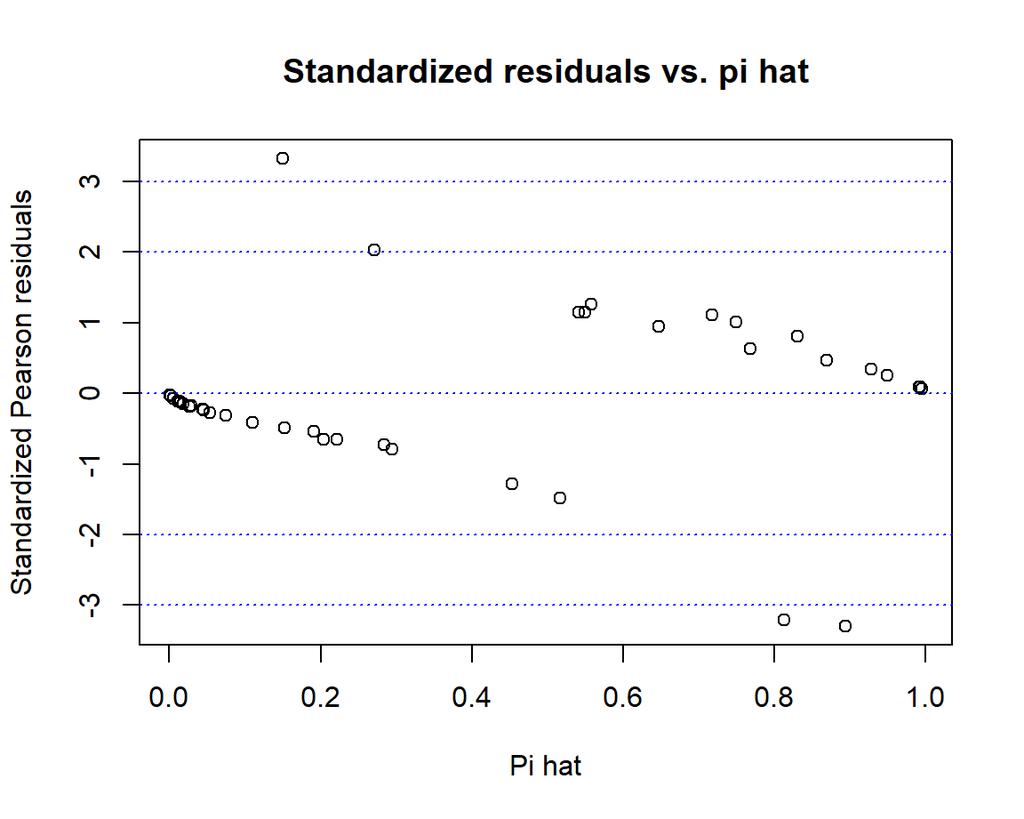

### Standardized residuals vs Linear Predictor

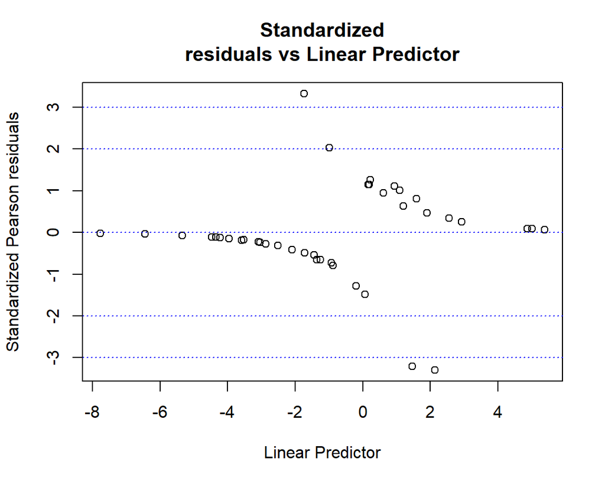

### R² values

```
Nagelkerke
 0.6497743
```

### Analysis of Anova

```
Analysis of Deviance Table (Type II tests)

Response: cmv
                 LR Chisq Df Pr(>Chisq)
diagnosis.type     0.4979  1    0.48041
prior.chemo        0.7421  1    0.38899
prior.transplant   3.4159  1    0.06457 .
donor.cmv          0.4962  1    0.48116
TBI.dose           4.2570  1    0.03909 *
c1c2ratio          3.8247  1    0.05050 .
agvhd              3.6252  1    0.05691 .
time.to.agvhd      0.0752  1    0.78395
cgvhd              1.0941  1    0.29557
time.to.cgvhd      2.3136  1    0.12825
---
Signif. codes:  0 '***' 0.001 '**' 0.01 '*' 0.05 '.' 0.1 ' ' 1
```

.

## comment tab

### Comment

These two tables show us that we have a couple of outliers.

# Obtainin prediction using Train & Test sets

.

### Predictions

```
 0  1
28 18
```

```
pred_traindata
 0  1
23 18
```

threshold = 0.4 because of the table above.

# Model Performances

### train set confusion matrix

```
Confusion Matrix and Statistics

          Reference
Prediction  0  1
         0 17  6
         1  8 10

               Accuracy : 0.6585
                 95% CI : (0.4941, 0.7992)
    No Information Rate : 0.6098
    P-Value [Acc > NIR] : 0.3191

                  Kappa : 0.2983

 Mcnemar's Test P-Value : 0.7893

            Sensitivity : 0.6800
            Specificity : 0.6250
         Pos Pred Value : 0.7391
         Neg Pred Value : 0.5556
             Prevalence : 0.6098
         Detection Rate : 0.4146
   Detection Prevalence : 0.5610
      Balanced Accuracy : 0.6525

       'Positive' Class : 0
```

### test set confusion matrix

```
Confusion Matrix and Statistics

          Reference
Prediction 0 1
         0 2 0
         1 1 2

               Accuracy : 0.8
                 95% CI : (0.2836, 0.9949)
    No Information Rate : 0.6
    P-Value [Acc > NIR] : 0.337

                  Kappa : 0.6154

 Mcnemar's Test P-Value : 1.000

            Sensitivity : 0.6667
            Specificity : 1.0000
         Pos Pred Value : 1.0000
         Neg Pred Value : 0.6667
             Prevalence : 0.6000
         Detection Rate : 0.4000
   Detection Prevalence : 0.4000
      Balanced Accuracy : 0.8333

       'Positive' Class : 0
```

.

### Results

```
       Accuracy Sensitivity Specificity  F1 Score
Train 0.6585366   0.6800000       0.625 0.7083333
Test  0.8000000   0.6666667       1.000 0.8000000
```

````r
---
title: "Cytomegalovirus"
output:
  flexdashboard::flex_dashboard:
    vertical_layout: fill
    orientation: rows
    social: menu
    source_code: embed
    runtime: Shiny
---

```{r message=FALSE, warning=FALSE}
library(ggplot2)
library(plotly)
library(plyr)
library(flexdashboard)
library(tidyverse)
library(medicaldata)
library(corrplot)
library(vcd)
library(GGally)
library(caret)
library(nnet)
library(lattice)
library(MASS)
library(dplyr)
library(lmtest)
library(DataExplorer)
library(DescTools)
library(car)
library(epiR)
library(vcd)
library(epitools)
```





EDA
=======================================================================



Column {data-width=650}
-----------------------------------------------------------------------

### Stars plot
```{r}
cytomegalovirus <- na.omit(cytomegalovirus)
colnames(cytomegalovirus)[19] <- "c1c2ratio"
#plot
stars(x=cytomegalovirus[order(cytomegalovirus$age),-1],ncol = 10,key.loc = c(17,1),draw.segments = TRUE,label=NULL,cex=0.5,key.xpd = TRUE)

```

### Age vs Frequency
```{r}
p <- ggplot(cytomegalovirus, aes(x = age))+
  geom_histogram(binwidth =2,fill = "skyblue", color = "black")+
  xlab("Age")

plotly::ggplotly(p)

```


Column {data-width=650}
-----------------------------------------------------------------------

### Diagnosis Types & Frequencies
```{r}
#another plot
p2 <- ggplot(cytomegalovirus, aes(y = diagnosis)) +
  geom_bar(fill = "skyblue", color = "black") +
  labs(title = "Bar Plot of Diagnosis ",
       y = "Diagnosis",
       x = "Count")
p2
```

### Correlation plot
```{r}
p3 <- cor(cytomegalovirus[,c(1,7,9,14,15,16,17,20,22,24,26)])
corrplot(p3, method = "color", type = "upper")



```

Comment tabs {.tabset}
------------------
### Comment

-In stars plot, I ordered the data with respect to increasing age.And The plot shows the numerical variables. From the plot, we can see that none of the variables are increasing or decreasing with age.
-The majority of patients in the data set are between 50-60 years old.
The mean age of the patients is approximately 53.
-The bar plot of diagnosis and their frequencies. Majority of people suffer from non-Hodgkin Lymphoma and Acute Myleoid Leukemia.
-This correlation matrix shows that there is multicollinearity problem between :
TNC dose  and CD8 dose,
CD3 dose and CD8 dose.








Distributions of Numerical variables
=======================================================================



Row
-----------------------------------------------------------------------
### Chart

```{r}
p4 <- ggplot(cytomegalovirus, aes(x =prior.chemo),color="blue")+
  geom_density(fill = alpha("skyblue",0.3), color = "black")+
  xlab("Prior chemotherapy Regimen")

plotly::ggplotly(p4)

```

### Chart

```{r}
p5 <- ggplot(cytomegalovirus, aes(x =time.to.transplant))+
  geom_density(fill = alpha("skyblue",0.3), color = "black",binwidth = 10)+
  xlab("Time To Transplant")

plotly::ggplotly(p5)
```


Column
-----------------------------------------------------------------------
### Chart

```{r}
p6 <- ggplot(cytomegalovirus, aes(x =TNC.dose))+
  geom_density(fill = alpha("skyblue",0.3), color = "black",binwidth = 2)+
  xlab("TNC dose")

plotly::ggplotly(p6)
```






Distributions for numerical variables
=======================================================================



Column {data-width=650}
-----------------------------------------------------------------------

### Chart

```{r}
p7 <- ggplot(cytomegalovirus, aes(x =CD3.dose),color="blue",width=3)+
  geom_density(fill = alpha("skyblue",0.3), color = "black")+
  xlab("Total CD3+ (T) cell dose (x 10^8/kg)")

plotly::ggplotly(p7)

```
Row
-----------------------------------------------------------------------


### Chart

```{r}
p9 <- ggplot(cytomegalovirus, aes(x = CD8.dose),color="blue")+
  geom_density(fill = alpha("skyblue",0.3), color = "black",)+
  xlab("Total CD8+ cell dose (x 10^8/kg)")

plotly::ggplotly(p9)

```



### Chart


```{r}
p10 <- ggplot(cytomegalovirus, aes(x =CD34.dose),color="blue")+
  geom_density(fill = alpha("skyblue",0.3), color = "black")+
  xlab("Total CD34+ (stem) cell dose (x 10^8/kg)")

plotly::ggplotly(p10)

```









Relation Plots
=======================================================================

Row
-----------------------------------------------------------------------
### Age VS Time from cancer diagnosis to transplant (months)
```{r}
p11 <- ggplot(cytomegalovirus, aes(x=age, y=time.to.transplant)) +
     geom_point(alpha = 0.5) +
     geom_density_2d() +
     theme(panel.background = element_rect(fill = '#ffffff'))
ggplotly(p11)
```

### Age Vs Time to cytomegalovirus reactivation
```{r}
p12<- ggplot(cytomegalovirus, aes(x = age, y = time.to.cmv , color = sex)) +
  geom_point() +
  labs( x = "Age",
       y = "Time to cytomegalovirus reactivation ",
       shape = "Gender")
ggplotly(p12)

```
comment tab {.tabset}
------------------
### Comment
-The density lines are concenctrated at the age 60. Which means, if the age of patients are close to 60, the time from cancer diagnosis to transplant decreases. But still, there are some patients whose age are under 40 and their time from diagnosis to transplant is low.



Relation Plots
=======================================================================

Column
-----------------------------------------------------------------------
### Chart

```{r}
p13 <- ggplot(cytomegalovirus, aes(x = diagnosis,y = age,fill=diagnosis)) +
  geom_boxplot() +
  coord_flip()+
  scale_fill_brewer(palette = "Set3") +
  labs(title = "Age x Diagnosis Boxplot", x = "Diagnosis", y = "Age")
ggplotly(p13)
```



```{r}
p14 <- ggplot(cytomegalovirus, aes(x = diagnosis,y = time.to.transplant ,fill=diagnosis)) +
  geom_boxplot() +
  coord_flip()+
  scale_fill_brewer(palette = "Set3") +
  labs(title = "diagnosis x transplant time Boxplot", x = "Diagnosis", y = "Time to transplant")
ggplotly(p14)
```





Relation Plots
=======================================================================
````

````r
Column
-----------------------------------------------------------------------
### Chart

```{r}
p15 <- ggplot(cytomegalovirus, aes(x = TNC.dose, y = CD34.dose,color=diagnosis)) +
  geom_point() +
  labs(title = "Scatter Plot of TNC Dose vs. CD34 Dose", x = "TNC Dose (x 10^8/kg)", y = "CD34 Dose (x 10^8/kg)")
ggplotly(p15)
```



### ChartB

```{r}
p16 <- ggplot(cytomegalovirus, aes(x = CD3.dose, y = CD8.dose,color = diagnosis)) +
  geom_point(shape = 16, size = 3, alpha = 0.7) +
  labs(title = "Scatter Plot of CD3 Dose vs. CD8 Dose", x = "CD3 Dose (x 10^8/kg)", y = "CD8 Dose (x 10^8/kg)")
ggplotly(p16)
```


Row
-----------------------------------------------------------------------

### Chart
```{r}
p17 <- ggplot(cytomegalovirus, aes(x = TNC.dose, y = CD8.dose,color = diagnosis)) +
  geom_point(shape = 16, size = 3, alpha = 0.7) +
  labs(title = "Scatter Plot of TNC Dose vs. CD8 Dose", x = "TNC Dose (x 10^8/kg)", y = "CD8 Dose (x 10^8/kg)")
ggplotly(p17)
```

comment tab {.tabset}
------------------
### Comment
In these plots, we can clearly see that when  TNC dose and CD3 dose increase,the CD8 dose also increase, which we observed in the correlation graph.



Relation Plots
=======================================================================

Row
-----------------------------------------------------------------------


### ChartA


```{r message=FALSE}


cytomegalovirus %>% dplyr::select(age, time.to.transplant, prior.chemo, TNC.dose, CD34.dose, CD3.dose, CD8.dose, time.to.cmv, time.to.agvhd, time.to.cgvhd) %>%
  ggpairs(columnLabels = c("age", "time.to.transplant", "prior.chemo", "TNC.dose", "CD34.dose", "CD3.dose", "CD8.dose", "time.to.cmv", "time.to.agvhd", "time.to.cgvhd"))

```



Contingency table analysis
=======================================================================

Row
-----------------------------------------------------------------------

### Gender vs Diagnosis Type



```{r}
x2table <- table(Sex = cytomegalovirus$sex, Diagnosis_Type= cytomegalovirus$diagnosis.type)
rownames(x2table) <- c("Male", "Female")
colnames(x2table) <- c("Myeloid", "Lymphoid")
x2table
```
### Odds Ratio
```{r}
oddsratio(x2table, method = "wald")$measure[-1,]
```
The odds ratio indicates that females have approximately 70% of the odds of being diagnosed with Myeloid or Lymphoid type compared to males.However,
95% Wald Confidence Interval suggests that there is no significant association between gender and diagnosis type. Because the interval includes 1.



Row
-----------------------------------------------------------------------

### Chi-Squared Test of Independence
H0: The variables in row and column are independent
H0: The variables in row and column are NOT independent


```{r}
chisq.test(x2table)
```


Our P-value is 0.76 ,which is greater than our alpha value 0.05 , we fail to reject null hypotesis. meaning that the variables are NOT associated.





Contingency table analysis
=======================================================================

Row
-----------------------------------------------------------------------

### Race vs Diagnosis Type



```{r}
x2table2 <- table(Race = cytomegalovirus$race, Diagnosis_Type= cytomegalovirus$diagnosis.type)
rownames(x2table2) <- c("White", "American/African")
colnames(x2table2) <- c("Myeloid", "Lymphoid")
x2table2
```



### Odds Ratio
```{r}
oddsratio(x2table2, method = "wald")$measure[-1,]
```
The odds ratio indicates that odds of American/African people being diagnosed with Myeloid or Lymphoid type is 3.3 times when compared to white people.



Row
-----------------------------------------------------------------------

### Chi-squared Test
H0: The variables in row and column are independent
H0: The variables in row and column are NOT independent


```{r}
chisq.test(x2table2)
```
We got a warning about Chi-square may be incorrect. Thats because Chi square statistic follows chi-squared distribution approximately. Chisq.test function  warns us we have one expected count lower than 5.So, it is better to use Fisher's Exact Test.


### Fisher's Exact Test
```{r}
fisher.test(x2table2)
```
P value being greater than 0.05 indicates we fail to reject H0,which means the race and diagnosis type is also not related to eachother.




















PMB (Purposeful selection for Modeling)
=======================================================================



Row
-----------------------------------------------------------------------

### Train & test data
```{r}
Train <- createDataPartition(cytomegalovirus$diagnosis,p = 0.8,list = FALSE)
traindata <- cytomegalovirus[Train,]
testdata <- cytomegalovirus[-Train,]
head(traindata,5)
names(traindata)
```
.

### 1) Constructing main effect models & collecting variables (if P<0.2)

```{r}
predictor_vars <- names(traindata)[-which(names(cytomegalovirus) == "cmv",)]
model_summaries <- list()
for (var in predictor_vars) {
  model_fit <- glm(paste("cmv ~", var), data = traindata, family = "binomial")
  model_summaries[[var]] <- summary(model_fit)
}

model_summaries
```
In the p values, we see that ID,age,sex,diagnosis,race,time.to.transplant,prior.radiation,
recipient.cmv,donor.sex,doses of TNC,DC3,DC8,DC34,aKIRs,time.to.cmv are insignificant.

Row
-----------------------------------------------------------------------


### Full model & backward elimination


```{r warning=FALSE}
fit1 <- glm(cmv~.-age-race-diagnosis-ID-sex-time.to.transplant-prior.radiation-recipient.cmv-donor.sex-TNC.dose-CD3.dose-CD8.dose-CD34.dose-aKIRs-time.to.cmv,data = traindata, family = "binomial")
summary(fit1)
backwardmodel <- stepAIC(fit1,direction = "backward")
summary(backwardmodel)
```
We got the model including prior.transplant,donor.cmv,c1/c2,agvhd,time.cgvhd variables. The AIC value is almost 50.


### Fit2 , the fitted model from backward elimination method

```{r warning=FALSE}
fit2 <- glm(cmv~+age+race+ID+sex+time.to.transplant+prior.radiation+recipient.cmv+donor.sex+TNC.dose+CD3.dose+CD8.dose+CD34.dose+aKIRs-time.to.cmv+donor.cmv+c1c2ratio+agvhd+time.to.cgvhd,data = traindata, family = "binomial")
summary(fit2)
```
Despite the AIC value, the model variables do not contribute to the model in any ways.
````

````r
Logistic Regression
=======================================================================



Row
-----------------------------------------------------------------------
### Fit3, the model from 1'st step (sole predictors)
Now, lets see if our significant variables (in 1st step) works
```{r}
fit3 <- glm(cmv~race+prior.chemo+recipient.cmv+donor.cmv+TBI.dose+time.to.transplant+c1c2ratio+time.to.cmv+agvhd+time.to.cgvhd,data = traindata)
summary(fit3)
```
.


### Significance test for 3rd fitted model (LRT)


```{r}
lrttest <- lrtest(fit1, fit2)
print(lrttest)
```
.

Row
-----------------------------------------------------------------------


### Hypotesis



H0:  there is NO significant difference in model fit between the full model and the reduced model

H1: there is a significant difference in model fit between the full model and the reduced model





### Commentary


Since our P- value is (0.6) > alpha value (0.05) we fail to reject H0, Which means there is NO significant difference in model fit between the full model and the reduced model. In other words, if we add more predictors, they do not improve the model fit.Since our full model AIC is 66 and our third model AIC is 42, The third  model is more appropriate for analysing







Checking diagnostics
=======================================================================



Row
-----------------------------------------------------------------------
### Standardized residuals vs. pi hat

```{r}
pi.hat <- predict(fit1 , type = "response") # Storing predicted response values
p.res <- residuals(fit1, type = "pearson") # Storing residuals
s.res <- rstandard(fit1, type = "pearson") # Std resiudals
lin.pred <- fit1$linear.predictors

plot (x = pi.hat, y=s.res, xlab = "Pi hat", ylab = "Standardized Pearson residuals", main = "Standardized residuals vs. pi hat")
abline (h = c(3, 2, 0, -2, -3) , lty = "dotted", col = "blue ")
```



### Standardized residuals vs Linear Predictor

```{r}
plot(x=lin.pred, y=s.res, xlab="Linear Predictor", ylab="Standardized Pearson residuals", main ="Standardized
residuals vs Linear Predictor")
abline(h = c(3, 2, 0, -2, -3) , lty = "dotted", col = "blue ")
```


Row
-----------------------------------------------------------------------


###  R² values



```{r}
DescTools::PseudoR2(fit1, which='Nagelkerke')
```
61% of the variation in the model is explained by our variables.



### Analysis of Anova

```{r}
car::Anova(fit1)
```
.

comment tab {.tabset}
------------------
### Comment
These two tables show us that we have a couple of outliers.


Obtainin prediction using Train & Test sets
=======================================================================

Row
-----------------------------------------------------------------------
### Train Set, first 5 rows


```{r}
Train <- createDataPartition(cytomegalovirus$diagnosis,p = 0.8,list = FALSE)
traindata <- cytomegalovirus[Train,]
testdata <- cytomegalovirus[-Train,]
head(traindata,5)
```
.


### Predictions

```{r}
pred_traindata <- ifelse(predict(fit3, type="response") < 0.4, 0,1)
pred_testdata <- ifelse(predict(fit3, newdata = testdata, type="response") < 0.4, 0,1)
table(cytomegalovirus$cmv)
table(pred_traindata)
```
threshold = 0.4 because of the table above.

i.e 28 / 48 = 0.39



```{r}
pred_traindata <- as.factor(pred_traindata)
pred_testdata <- as.factor(pred_testdata)
```





Model Performances
=======================================================================



Row
-----------------------------------------------------------------------
### train set confusion matrix
See the model performance metrics of the full model:
```{r}
cm_traindata <- confusionMatrix(data = pred_traindata, reference=as.factor(traindata$cmv))
cm_traindata
```



### test set confusion matrix

```{r}
cm_testdata <- confusionMatrix(data=pred_testdata, reference=as.factor(testdata$cmv))
cm_testdata
```
.

Row
-----------------------------------------------------------------------


### Results


```{r}
results <- matrix(c(cm_traindata$overall[1],cm_traindata$byClass[1], cm_traindata$byClass[2], cm_traindata$byClass[7],
                         cm_testdata$overall[1],cm_testdata$byClass[1], cm_testdata$byClass[2], cm_testdata$byClass[7]), byrow =T, nrow=2)
colnames(results) <- c("Accuracy","Sensitivity","Specificity","F1 Score")
rownames(results) <- c("Train", "Test")

results
```
The reduced model is seemed to have a good match for both the dataset and the unseen portion of the data because all train and test metrics are high enough.
````